# Herding in Tech stocks

### What is Herding

The phrase herd instinct alludes to a phenomena in which someone join groups and imitate the actions of others on the belief that others have already conducted the necessary research. Even in the financial industry, where investors imitate what they believe other investors are doing rather than depending on their own research, herd tendencies remain widespread. An investor who demonstrates herd instinct tends to gravitate toward the same or comparable decisions the market is making in a broader sense.

Here i will try to explore the top tech stocks and see if there is a herding pattern in these stocks by looking at the closing prices of these stocks for a period of one year. We will try to see if the price movements in these stocks are based on their own performances or largely based on general trends in the market that reflects across all stocks, showing some patterns of herding.

### Data Description

The prices were downloaded individually from Yahoo Finance and merged into a CSV file that I’ll be using for further analysis.

### Methodology

I will be using Cross sectional Absolute deviation to see if there is herding present in the technology stocks. I’ll employ the return dispersion model presented by Chang et al., that is an improvement on the framework suggested by Christie and Huang, to evaluate investment herding behavior.

I use the CSAD of returns as a measure of return dispersion formulated as follows:

$CSADt= 1/M \sum_{i=1}^{M} ∣R_{(i,t)}−R_{(m,t)}∣$

If herding occurs, the link with CSAD and stock returns will become less positive and linear, or perhaps even negative and nonlinear. This phenomena emerges as a result of the correlation between herding and a decline in CSAD and a rise in extreme returns.

First I load the libraries and data sets that we created for the technology stock closing prices for past one year.

```r
require (xts) # the package to work with xts objects require (zoo) # the package to work with zoo objects
library (PerformanceAnalytics) # the package to calculate return automatically
require (sandwich)
require(lmtest)
## load the data
closingPrice = read.csv("close_prices.csv", header = TRUE) # import the datafile
```

Now I will be parsing the date column and then proceed to convert the dataframe into a time series object so that calculating features like Lag and return would be easier

```r
closingPrice$Date = as.POSIXct(closingPrice$Date,format="%d/%m/%Y", tz = "") # change the type of the first column
closingPrice.xts <- xts(closingPrice[,-1], order.by=closingPrice[,1]) # transform the dataframe into xts object
closingPrice.zoo <- as.zoo(closingPrice.xts) # transfporm into zoo object
```

I calculate the return for each day

```r
return = Return.calculate( closingPrice.xts , method = "log")
```

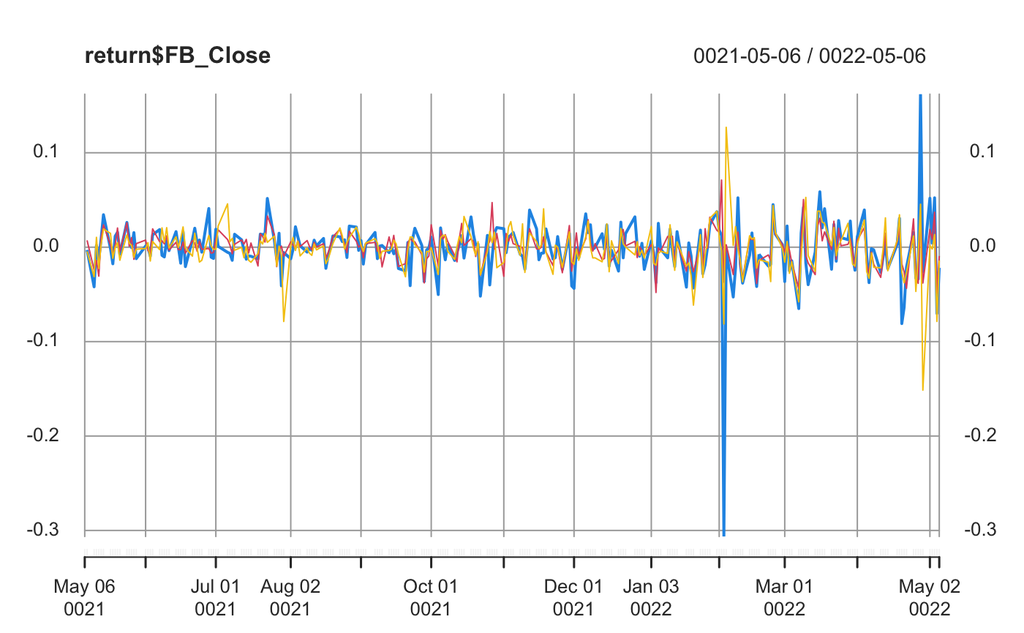

```r
plt = plot(return$FB_Close, col = 4)
plt =   lines(return$GO_Close, col = 2)
plt =  lines(return$AM_Close, col = 7)
show(plt)
```

We can observe that the returns in all the stocks are very much aligned and follow similar trends.

I created a function for calculation of CSAD I calculate CSAD in the following manner:

$CSAD = rowSums(|return-rowMeans(return) |) /ncol(return)$)

```r
# a function to create CSAD (Cross sectional absolute deviation)
exch_herd = function(return) {
n=ncol(return)
Rm = rowMeans(return)
temp_dif =abs(return-Rm)
temp_sum = rowSums(temp_dif)
CSAD = temp_sum / ncol(return)
CSAD = cbind (CSAD, Rm)
return (CSAD)
}
```

I call the CSAD function by passing our return values we calculated previously

```r
f = exch_herd(return)
head (f)
```

```
            CSAD           Rm
[1,]          NA           NA
[2,] 0.005504296  0.001796420
[3,] 0.009650974 -0.026927568
[4,] 0.008777531 -0.002653061
[5,] 0.004617592 -0.021993533
[6,] 0.002766387  0.008551757
```

Now I will proceed to perform a regression on our CSAD values

First I create a dataframe with the CSAD values from the function

```r
CSAD.df = fortify.zoo(f)
CSAD.df$Rm2 = CSAD.df$Rm^2
CSAD.df = CSAD.df[-c(1),]
head (CSAD.df)
```

|  | Index | CSAD | Rm | Rm2 |
| --- | --- | --- | --- | --- |
| 2 | 2 | 0.005504296 | 0.001796420 | 3.227124e-06 |
| 3 | 3 | 0.009650974 | -0.026927568 | 7.250939e-04 |
| 4 | 4 | 0.008777531 | -0.002653061 | 7.038735e-06 |
| 5 | 5 | 0.004617592 | -0.021993533 | 4.837155e-04 |
| 6 | 6 | 0.002766387 | 0.008551757 | 7.313255e-05 |
| 7 | 7 | 0.006002681 | 0.023028781 | 5.303248e-04 |

```r
tail (CSAD.df)
```

|  | Index | CSAD | Rm | Rm2 |
| --- | --- | --- | --- | --- |
| 249 | 249 | 0.044175005 | -0.063047965 | 3.975046e-03 |
| 250 | 250 | 0.016142308 | 0.019524850 | 3.812198e-04 |
| 251 | 251 | 0.002911418 | 0.003840981 | 1.475313e-05 |
| 252 | 252 | 0.011601695 | 0.033009538 | 1.089630e-03 |
| 253 | 253 | 0.015932027 | -0.058441488 | 3.415408e-03 |
| 254 | 254 | 0.005247940 | -0.012768128 | 1.630251e-04 |

```r
y = CSAD.df$CSAD
x1 = abs (CSAD.df$Rm)
x2 =CSAD.df$Rm2
variables.ready = cbind (y, x1, x2)
```

We apply linear regression where dependent variable in CSAD values of each day, and explanatory variables are RM and RM^2

```r
linearMod <- lm(y~x1+x2) # build linear regression model on full data
print(linearMod)
```

```
Call:
lm(formula = y ~ x1 + x2)

Coefficients:
(Intercept)           x1           x2
   0.005477    -0.016723     7.456498
```

This is the summary of our regression model on the CSAD values of the tech stocks

```r
summary(linearMod)
```

```
Call:
lm(formula = y ~ x1 + x2)

Residuals:
      Min        1Q    Median        3Q       Max
-0.014034 -0.002664 -0.000871  0.001043  0.033971

Coefficients:
              Estimate Std. Error t value Pr(>|t|)
(Intercept)  0.0054769  0.0005127  10.682   <2e-16 ***
x1          -0.0167235  0.0462518  -0.362    0.718
x2           7.4564980  0.6229241  11.970   <2e-16 ***
---
Signif. codes:  0 ‘***’ 0.001 ‘**’ 0.01 ‘*’ 0.05 ‘.’ 0.1 ‘ ’ 1

Residual standard error: 0.004844 on 250 degrees of freedom
Multiple R-squared:  0.6662,    Adjusted R-squared:  0.6635
F-statistic: 249.5 on 2 and 250 DF,  p-value: < 2.2e-16
```

```r
coeftest(linearMod,vcov=NeweyWest(linearMod,verbose=T))
```

```
Lag truncation parameter chosen: 0

t test of coefficients:

               Estimate  Std. Error t value Pr(>|t|)
(Intercept)  0.00547688  0.00054164 10.1116   <2e-16 ***
x1          -0.01672347  0.06892467 -0.2426   0.8085
x2           7.45649802  0.62397621 11.9500   <2e-16 ***
---
Signif. codes:  0 ‘***’ 0.001 ‘**’ 0.01 ‘*’ 0.05 ‘.’ 0.1 ‘ ’ 1
```

### Estimting with TV Linear Regression

```r
require (tvReg)
tvlm.fit = tvLM(y~x1+x2, bw = NULL  ) #bw=0.149
```

```
Calculating regression bandwidth... bw =  20
```

```r
head (tvlm.fit$coefficients)
```

```
     (Intercept)          x1       x2
[1,] 0.005475422 -0.01658755 7.454944
[2,] 0.005475435 -0.01658860 7.454955
[3,] 0.005475447 -0.01658964 7.454966
[4,] 0.005475460 -0.01659069 7.454977
[5,] 0.005475473 -0.01659174 7.454988
[6,] 0.005475485 -0.01659279 7.454999
```

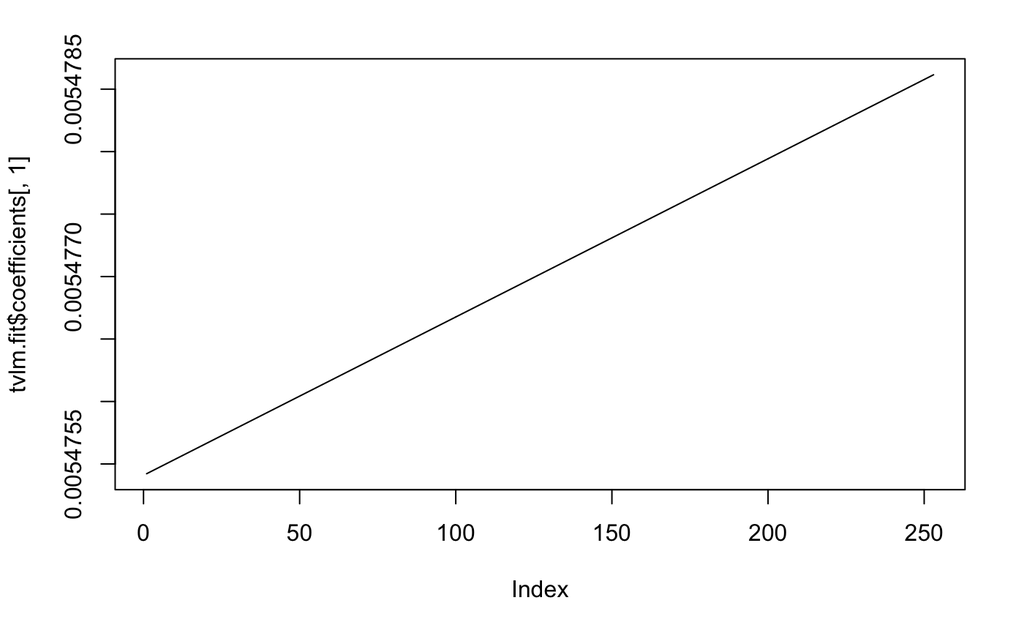

```r
plot(tvlm.fit$coefficients[,1], type="l")
```

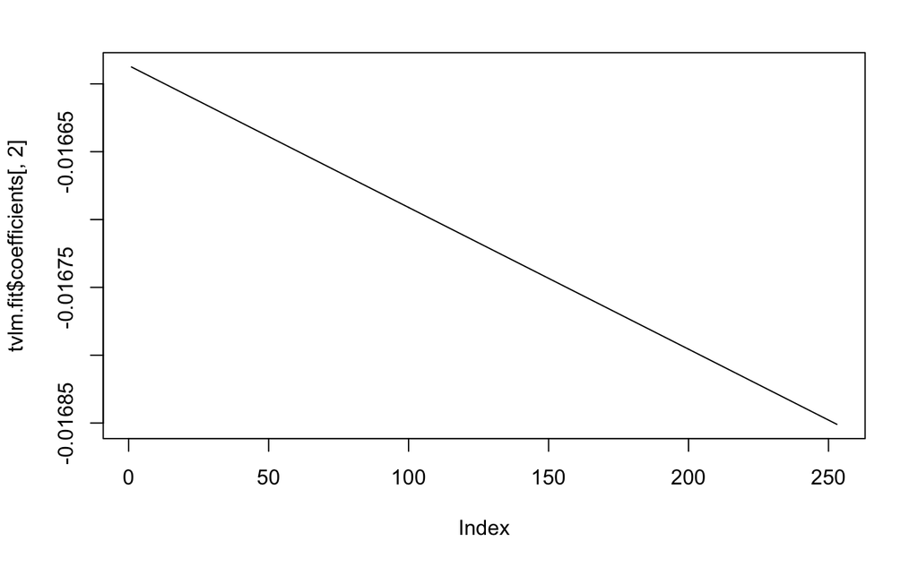

```r
plot(tvlm.fit$coefficients[,2], type="l")
```

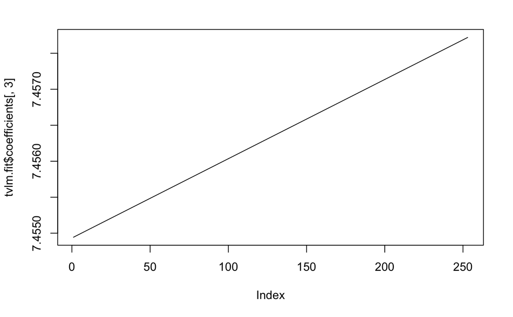

```r
plot(tvlm.fit$coefficients[,3], type="l")
```

### Estimting with Bayesian models

```r
library (brms)
hourly = cbind(y, x1, x2)
model = brm(formula = y ~ x1+x2,
            data    = hourly,
            seed    = 123)
summary(model)
```

```
 Family: gaussian
  Links: mu = identity; sigma = identity
Formula: y ~ x1 + x2
   Data: hourly (Number of observations: 253)
  Draws: 4 chains, each with iter = 2000; warmup = 1000; thin = 1;
         total post-warmup draws = 4000

Population-Level Effects:
          Estimate Est.Error l-95% CI u-95% CI Rhat Bulk_ESS Tail_ESS
Intercept     0.01      0.00     0.00     0.01 1.00     2112     2453
x1           -0.02      0.05    -0.11     0.08 1.00     1264     1512
x2            7.46      0.61     6.21     8.61 1.00     1247     1166

Family Specific Parameters:
      Estimate Est.Error l-95% CI u-95% CI Rhat Bulk_ESS Tail_ESS
sigma     0.00      0.00     0.00     0.01 1.00     1404     1528

Draws were sampled using sampling(NUTS). For each parameter, Bulk_ESS
and Tail_ESS are effective sample size measures, and Rhat is the potential
scale reduction factor on split chains (at convergence, Rhat = 1).
```

```r
library (quantreg)
taus<-seq(from = .1, to = .9, by = .1)
#coef0 <- rq( y ~ x1+x2, tau=taus)
#summary (coef0)
```

# Part 2, for Up and Down markets

We will split the data into positive and negative days where returns are positive or negative respectively in the S&P500 index

```r
pos_return <- return[which(return$SNP_500_Close > 0),]
neg_return <- return[which(return$SNP_500_Close < 0),]
```

### Herding in UP market

```r
pos_f = exch_herd(pos_return)
head (pos_f)
```

```
            CSAD          Rm
[1,] 0.005504296 0.001796420
[2,] 0.002766387 0.008551757
[3,] 0.006002681 0.023028781
[4,] 0.005198724 0.012899247
[5,] 0.007317570 0.018748523
[6,] 0.003369372 0.003363337
```

```r
pos.CSAD.df = fortify.zoo(pos_f) # converting f into a dataframe (to simplify further calculations)
pos.CSAD.df$Rm2 = pos.CSAD.df$Rm^2 # calculating Rm^2
pos.CSAD.df = pos.CSAD.df[-c(1),] # removing the first row with NAs
head (pos.CSAD.df) # show the first 6 rows
```

|  | Index | CSAD | Rm | Rm2 |
| --- | --- | --- | --- | --- |
| 2 | 2 | 0.002766387 | 0.008551757 | 7.313255e-05 |
| 3 | 3 | 0.006002681 | 0.023028781 | 5.303248e-04 |
| 4 | 4 | 0.005198724 | 0.012899247 | 1.663906e-04 |
| 5 | 5 | 0.007317570 | 0.018748523 | 3.515071e-04 |
| 6 | 6 | 0.003369372 | 0.003363337 | 1.131204e-05 |
| 7 | 7 | 0.010050264 | -0.001760424 | 3.099093e-06 |

```r
tail (pos.CSAD.df) # show the last 6 rows
```

|  | Index | CSAD | Rm | Rm2 |
| --- | --- | --- | --- | --- |
| 128 | 128 | 0.007094857 | 0.015755196 | 2.482262e-04 |
| 129 | 129 | 0.016313226 | -0.019675187 | 3.871130e-04 |
| 130 | 130 | 0.047349808 | 0.067364793 | 4.538015e-03 |
| 131 | 131 | 0.016142308 | 0.019524850 | 3.812198e-04 |
| 132 | 132 | 0.002911418 | 0.003840981 | 1.475313e-05 |
| 133 | 133 | 0.011601695 | 0.033009538 | 1.089630e-03 |

#### reassign my columns as Y and Xs to look better in the regression model

```r
pos.y = pos.CSAD.df$CSAD  # reassign my columns as Y and Xs to look better in the regression model
pos.x1 = abs (pos.CSAD.df$Rm)
pos.x2 = pos.CSAD.df$Rm2
```

#### Linear model

```r
linearMod2 <- lm(pos.y ~ pos.x1 + pos.x2)  # build linear regression model on full data
print(linearMod2)
```

```
Call:
lm(formula = pos.y ~ pos.x1 + pos.x2)

Coefficients:
(Intercept)       pos.x1       pos.x2
   0.005404    -0.011427     9.236606
```

```r
summary(linearMod2)
```

```
Call:
lm(formula = pos.y ~ pos.x1 + pos.x2)

Residuals:
      Min        1Q    Median        3Q       Max
-0.008440 -0.002767 -0.000915  0.000823  0.031935

Coefficients:
              Estimate Std. Error t value Pr(>|t|)
(Intercept)  0.0054043  0.0008147   6.634 8.16e-10 ***
pos.x1      -0.0114272  0.0957491  -0.119    0.905
pos.x2       9.2366056  2.0051010   4.607 9.70e-06 ***
---
Signif. codes:  0 ‘***’ 0.001 ‘**’ 0.01 ‘*’ 0.05 ‘.’ 0.1 ‘ ’ 1

Residual standard error: 0.004955 on 129 degrees of freedom
Multiple R-squared:  0.4246,    Adjusted R-squared:  0.4157
F-statistic:  47.6 on 2 and 129 DF,  p-value: 3.286e-16
```

### Herding in DOWN market

```r
neg_f = exch_herd(neg_return)
head (neg_f) # show the first 6 rows
```

```
            CSAD           Rm
[1,] 0.009650974 -0.026927568
[2,] 0.008777531 -0.002653061
[3,] 0.004617592 -0.021993533
[4,] 0.005709074  0.003209518
[5,] 0.003245212 -0.011409821
[6,] 0.004467017  0.002709125
```

```r
neg.CSAD.df = fortify.zoo(neg_f) # converting f into a dataframe (to simplify further calculations)
neg.CSAD.df$Rm2 = neg.CSAD.df$Rm^2 # calculating Rm^2
neg.CSAD.df = neg.CSAD.df[-c(1),] # removing the first row with NAs
head (neg.CSAD.df) # show the first 6 rows
```

|  | Index | CSAD | Rm | Rm2 |
| --- | --- | --- | --- | --- |
| 2 | 2 | 0.008777531 | -0.002653061 | 7.038735e-06 |
| 3 | 3 | 0.004617592 | -0.021993533 | 4.837155e-04 |
| 4 | 4 | 0.005709074 | 0.003209518 | 1.030101e-05 |
| 5 | 5 | 0.003245212 | -0.011409821 | 1.301840e-04 |
| 6 | 6 | 0.004467017 | 0.002709125 | 7.339359e-06 |
| 7 | 7 | 0.003966591 | -0.006696363 | 4.484128e-05 |

```r
tail (neg.CSAD.df) # show the last 6 rows
```

|  | Index | CSAD | Rm | Rm2 |
| --- | --- | --- | --- | --- |
| 115 | 115 | 0.015083660 | -0.03558146 | 0.0012660402 |
| 116 | 116 | 0.006781116 | -0.02998148 | 0.0008988889 |
| 117 | 117 | 0.006032311 | -0.03476576 | 0.0012086578 |
| 118 | 118 | 0.044175005 | -0.06304796 | 0.0039750459 |
| 119 | 119 | 0.015932027 | -0.05844149 | 0.0034154076 |
| 120 | 120 | 0.005247940 | -0.01276813 | 0.0001630251 |

```r
neg.y = neg.CSAD.df$CSAD  # reassign my columns as Y and Xs to look better in the regression model
neg.x1 = abs (neg.CSAD.df$Rm)
neg.x2 = neg.CSAD.df$Rm2
```

#### Linear model

```r
summary(linearMod3)
```

```
Call:
lm(formula = neg.y ~ neg.x1 + neg.x2)

Residuals:
      Min        1Q    Median        3Q       Max
-0.011443 -0.003674 -0.001571  0.002327  0.020991

Coefficients:
             Estimate Std. Error t value Pr(>|t|)
(Intercept) 0.0081431  0.0009217   8.835 1.26e-14 ***
neg.x1      0.1888973  0.0829539   2.277   0.0246 *
neg.x2      4.3732056  0.8004314   5.464 2.70e-07 ***
---
Signif. codes:  0 ‘***’ 0.001 ‘**’ 0.01 ‘*’ 0.05 ‘.’ 0.1 ‘ ’ 1

Residual standard error: 0.006245 on 116 degrees of freedom
Multiple R-squared:  0.6678,    Adjusted R-squared:  0.6621
F-statistic: 116.6 on 2 and 116 DF,  p-value: < 2.2e-16
```

Coefficient of X2, which is $R^2_{(m,t)}$ is not negative meaning there is no evidence of herding